# Final Report

Roba Abbajabal, Conor O’Shea, Aadhi Subbiah, Daniel Nass

11/11/2023

### Introduction

- For our research, we wished to analyze transportation safety in the US by state from 2010-2021.
- This involved observing fatalities by state and year, and then connecting that information with outside sources.
- This research particularly interests us, because we wish to find reasons of what may cause safer roads.

### Research Title: An Analysis on Transportation Safety in the US

### Team Members: Roba Abbajabal, Conor O’Shea, Aadhi Subbiah, Daniel Nass

#### Description of Data:

This data set contains information from 2010-2021 regarding fatal vehicular accidents that have occurred on highways within the United States by state/territory. The data can be accessed at the following link: https://www.bts.gov/browse-statistical-products-and-data/state-transportation-statistics/transportation-safety The variables included in this dataset are as follows:

- State: the state that the information comes from
- Fatality Type: A factor of 14 different types of fatalities (such as highway fatalities, SUV fatalities, etc.)
  - Highway Fatalities
  - Passenger Car Fatalities
  - SUV Fatalities
  - Pickup Truck Fatalities
  - Van Fatalities
  - Other Light Truck Fatalities
  - Motorcycle Fatalities
  - Bus Fatalities - Large Truck Fatalities
  - Pedalcyclist Fatalities
  - Pedestrian Fatalities
  - Other Nonoccupant Fatalities
  - Other Vehicle Fatalities
  - Unknown Person Type Fatalities
- Year: The year, from 2010 to 2021, of the number of a specific type of fatality in a state occured.
- TotalFatalities: the sum of all fatalities for each FatalityType and by year for overall and by each state.

#### Supplementary Datasets Used:

- Name: The state that information comes from.
- POPESTIMATE([2010-2021]): The population estimates for year ([2010-2021]).

**State Highway Travel** (2010-2021) [vehicles_traveleld_licensed_drivers_2010_2021.csv]: The Highway Statistics Series consists of annual reports containing analyzed statistical information on motor fuel, motor vehicle registrations, driver licenses, highway user taxation, highway mileage, travel, and highway finance. These information are presented in tables as well as selected charts. It has been published annually since 1945. This data can be accessed using the following link: https://www.bts.gov/browse-statistical-products-and-data/state-transportation-statistics/state-highway-travel This dataset will be used for reporting the number of miles driven each year and the number of licensed drivers per state The variables that are being used are as follows:

- State: the name of the state the information is from
- Measures: A factor of 2 different types of data
- Licensed drivers - Highway vehicle-miles traveled (millions)
- Year of Year: year the information is from (2010-2021)
- Values: value of measure factor

**State Financials (2019)** [ASFIN_FY2019.csv]: This dataset from Census.gov contains information in year 2019 regarding state revenue and expenditure from different sources. We used this data to show what correlation traffic fatalities may have with state financial data in the year 2019. The year 2019 was chosen because it was the year before COVID-19 arrived to the United States, which we later saw had it’s own impact on traffic fatalities. The variables in the dataset (after using pivot_longer) are as follows:

- State: The name of the state the information is collected form.
- Amount (Per 1000): The amount per $1000 dollars of state revenue or expenditure per category.
- RevenueType: The type of revenue or expenditure being reported.

#### Investigations:

Here, we came up with a couple of key questions to use when exploring our data, looking to specifically answer these questions and explore more.

- What is the leading cause of highway fatalities overall/by state?
- What states, if any, have stark contrasts in vehicular fatalities?
- Do these states have any laws or regulations that would cause this?
- Do any types of vehicular fatalities correlate with another?
- Have counts of certain types of vehicular fatalities increased or decreased over time?
- How did the COVID-19 pandemic during 2021 affect traffic fatalities?
- Is there a correlation between state revenue/spending and traffic fatalities?

#### Main:

The data does not account directly for population density. The data is raw numbers, and in order to get a better insight into what the data means we have to look at it by state.

### Data Setup

#### Highway Fatalities dataset being used

```
##           State                            X  X2010  X2011  X2012  X2013  X2014
## 1 United States           Highway Fatalities 32,999 32,479 33,782 32,893 32,744
## 2 United States     Passenger Car Fatalities 12,491 12,014 12,361 12,037 11,947
## 3 United States               SUV Fatalities  3,942  3,884  3,885  3,831  3,800
## 4 United States      Pickup Truck Fatalities  4,486  4,270  4,343  4,175  4,249
## 5 United States               Van Fatalities  1,346  1,128  1,167  1,142  1,021
## 6 United States Other Light Truck Fatalities      8     20     23     38     33
##    X2015  X2016  X2017  X2018  X2019  X2020  X2021 TotalFatalities
## 1 35,484 37,806 37,473 36,835 36,355 39,007 42,939         430,796
## 2 12,763 13,508 13,477 12,888 12,355 12,628 13,529         151,998
## 3  4,213  4,462  4,610  4,554  4,727  6,015  6,961          54,884
## 4  4,471  4,470  4,335  4,267  4,213  4,333  4,757          52,369
## 5  1,128  1,240  1,175  1,081  1,025    938  1,078          13,469
## 6     66    107     66     55     52      0      0             468
```

#### Summary of the Highway Fatalities dataset

```
##     State                X                X2010              X2011
##  Length:756         Length:756         Length:756         Length:756
##  Class :character   Class :character   Class :character   Class :character
##  Mode  :character   Mode  :character   Mode  :character   Mode  :character
##     X2012              X2013              X2014              X2015
##  Length:756         Length:756         Length:756         Length:756
##  Class :character   Class :character   Class :character   Class :character
##  Mode  :character   Mode  :character   Mode  :character   Mode  :character
##     X2016              X2017              X2018              X2019
##  Length:756         Length:756         Length:756         Length:756
##  Class :character   Class :character   Class :character   Class :character
##  Mode  :character   Mode  :character   Mode  :character   Mode  :character
##     X2020              X2021           TotalFatalities
##  Length:756         Length:756         Length:756
##  Class :character   Class :character   Class :character
##  Mode  :character   Mode  :character   Mode  :character
```

#### State Populations dataset form 2010-2021 being used

```
##           State     Y2010     Y2011     Y2012     Y2013     Y2014     Y2015
## 1 United States 309327143 311583481 313877662 316059947 318386329 320738994
## 2       Alabama   4785514   4799642   4816632   4831586   4843737   4854803
## 3        Alaska    713982    722349    730810    737626    737075    738430
## 4       Arizona   6407342   6473416   6556344   6634690   6732873   6832810
## 5      Arkansas   2921998   2941038   2952876   2960459   2968759   2979732
## 6    California  37319550  37636311  37944551  38253768  38586706  38904296
##       Y2016     Y2017     Y2018     Y2019     Y2020     Y2021
## 1 323071755 325122128 326838199 328329953 329484123 331893745
## 2   4866824   4877989   4891628   4907965   4921532   5039877
## 3    742575    740983    736624    733603    731158    732673
## 4   6944767   7048088   7164228   7291843   7421401   7276316
## 5   2991815   3003855   3012161   3020985   3030522   3025891
## 6  39149186  39337785  39437463  39437610  39368078  39237836
```

#### Summary of the State Populations dataset

```
##     State               Y2010               Y2011               Y2012
##  Length:53          Min.   :   564531   Min.   :   567491   Min.   :   576656
##  Class :character   1st Qu.:  1829591   1st Qu.:  1840914   1st Qu.:  1853691
##  Mode  :character   Median :  4348464   Median :  4370817   Median :  4387865
##                     Mean   : 11742940   Mean   : 11827277   Mean   : 11913015
##                     3rd Qu.:  6743009   3rd Qu.:  6827479   3rd Qu.:  6898599
##                     Max.   :309327143   Max.   :311583481   Max.   :313877662
##      Y2013               Y2014               Y2015
##  Min.   :   582620   Min.   :   583159   Min.   :   586389
##  1st Qu.:  1854768   1st Qu.:  1850569   1st Qu.:  1843332
##  Median :  4406906   Median :  4416992   Median :  4429126
##  Mean   : 11994584   Mean   : 12081274   Mean   : 12168891
##  3rd Qu.:  6966252   3rd Qu.:  7057531   3rd Qu.:  7167287
##  Max.   :316059947   Max.   :318386329   Max.   :320738994
##      Y2016               Y2017               Y2018
##  Min.   :   585243   Min.   :   579994   Min.   :   579054
##  1st Qu.:  1832435   1st Qu.:  1818683   1st Qu.:  1805953
##  Median :  4440306   Median :  4455590   Median :  4464273
##  Mean   : 12255664   Mean   : 12331501   Mean   : 12393769
##  3rd Qu.:  7299961   3rd Qu.:  7427951   3rd Qu.:  7526793
##  Max.   :323071755   Max.   :325122128   Max.   :326838199
##      Y2019               Y2020               Y2021
##  Min.   :   580116   Min.   :   582328   Min.   :   578803
##  1st Qu.:  1795263   1st Qu.:  1826913   1st Qu.:  1900923
##  Median :  4472345   Median :  4477251   Median :  4509394
##  Mean   : 12450065   Mean   : 12492973   Mean   : 12585869
##  3rd Qu.:  7614024   3rd Qu.:  7693612   3rd Qu.:  7738692
##  Max.   :328329953   Max.   :329484123   Max.   :331893745
```

#### State Highway Travel dataset: 2010-2021 being used

```
##           State                                      Type Year     Count
## 1 United States Highway vehicle-miles traveled (millions) 2021   3153957
## 2 United States                          Licensed drivers 2021 232781797
## 3 United States Highway vehicle-miles traveled (millions) 2020   2917383
## 4 United States                          Licensed drivers 2020 228195802
## 5 United States Highway vehicle-miles traveled (millions) 2019   3276482
## 6 United States                          Licensed drivers 2019 228679719
```

#### Summary of the State Highway Travel dataset

```
##     State               Type                Year          Count
##  Length:1416        Length:1416        Min.   :2010   Min.   :     1106
##  Class :character   Class :character   1st Qu.:2013   1st Qu.:    31680
##  Mode  :character   Mode  :character   Median :2016   Median :   124785
##                                        Mean   :2016   Mean   :  3797734
##                                        3rd Qu.:2018   3rd Qu.:  2606812
##                                        Max.   :2021   Max.   :232781797
```

### Data Cleanup:

##### We started with basic things like fixing empty column names and filtering the dataset to only include states. We also used the R state map dataset in order to create plots. Finally, we realized that population density was not accounted for in the initial data we found, then pulled the population data from the U.S. Census Bureau for the years and joined it with our dataset.

#### Creating a second dataset where there the whole country collectively is not included (just states and territories individually)

```
##     State                 FatalityType Y2010 Y2011 Y2012 Y2013 Y2014 Y2015
## 1 alabama           Highway Fatalities   862   895   865   853   820   850
## 2 alabama     Passenger Car Fatalities   376   389   370   357   337   355
## 3 alabama               SUV Fatalities   125   112   112   137   116   111
## 4 alabama      Pickup Truck Fatalities   153   154   140   151   150   156
## 5 alabama               Van Fatalities    33    27    26    20    15    23
## 6 alabama Other Light Truck Fatalities     2     1     0     1     0     3
##   Y2016 Y2017 Y2018 Y2019 Y2020 Y2021 TotalFatalities
## 1 1,083   948   953   930   934   983          10,976
## 2   416   395   411   362   371   368           4,507
## 3   166   143   136   126   166   182           1,632
## 4   165   145   149   160   152   131           1,806
## 5    24    27    19    21    16    40             291
## 6     9     1     1     4     0     0              22
```

#### Summary of newly created states dataset

```
##     State           FatalityType           Y2010             Y2011
##  Length:742         Length:742         Min.   :   0.00   Min.   :   0.00
##  Class :character   Class :character   1st Qu.:   1.00   1st Qu.:   1.00
##  Mode  :character   Mode  :character   Median :  13.00   Median :  13.00
##                                        Mean   :  91.61   Mean   :  90.23
##                                        3rd Qu.:  70.00   3rd Qu.:  70.25
##                                        Max.   :3023.00   Max.   :3054.00
##                                        NA's   :14        NA's   :14
##      Y2012             Y2013             Y2014             Y2015
##  Min.   :   0.00   Min.   :   0.00   Min.   :   0.00   Min.   :   0.00
##  1st Qu.:   1.00   1st Qu.:   1.00   1st Qu.:   1.00   1st Qu.:   1.00
##  Median :  13.00   Median :  13.00   Median :  13.00   Median :  13.50
##  Mean   :  93.83   Mean   :  91.34   Mean   :  90.84   Mean   :  98.36
##  3rd Qu.:  75.00   3rd Qu.:  71.50   3rd Qu.:  69.00   3rd Qu.:  75.00
##  Max.   :3408.00   Max.   :3389.00   Max.   :3536.00   Max.   :3582.00
##  NA's   :14        NA's   :14        NA's   :14        NA's   :14
##      Y2016            Y2017             Y2018             Y2019
##  Min.   :   0.0   Min.   :   0.00   Min.   :   0.00   Min.   :   0.0
##  1st Qu.:   2.0   1st Qu.:   2.00   1st Qu.:   1.75   1st Qu.:   2.0
##  Median :  17.0   Median :  15.00   Median :  15.00   Median :  14.0
##  Mean   : 104.6   Mean   : 103.76   Mean   : 102.02   Mean   : 100.7
##  3rd Qu.:  81.0   3rd Qu.:  79.25   3rd Qu.:  80.50   3rd Qu.:  78.0
##  Max.   :3837.0   Max.   :3884.00   Max.   :3798.00   Max.   :3719.0
##  NA's   :14       NA's   :14        NA's   :14        NA's   :14
##      Y2020            Y2021         TotalFatalities
##  Min.   :   0.0   Min.   :   0.00   Min.   :    0.0
##  1st Qu.:   1.0   1st Qu.:   1.00   1st Qu.:   18.0
##  Median :  16.0   Median :  17.00   Median :  174.0
##  Mean   : 107.8   Mean   : 118.85   Mean   : 1194.0
##  3rd Qu.:  79.0   3rd Qu.:  91.25   3rd Qu.:  920.2
##  Max.   :3980.0   Max.   :4498.00   Max.   :43162.0
##  NA's   :14       NA's   :14        NA's   :14
```

### Data Exploration

#### Plan of Data Exploration

##### Break down each fatality type and plot the data by state, observe similarities and differences between the states for each fatality type. First, we constructed the dataframe of fatality by year, and then we constructed dataframe of fatality by state.

##### This data shows the states used to construct our plots and to seperate the data by state.

```
##     State       FatalityType Y2010 Y2011 Y2012 Y2013 Y2014 Y2015 Y2016 Y2017
## 1 alabama Highway Fatalities   862   895   865   853   820   850  1083   948
## 2 alabama Highway Fatalities   862   895   865   853   820   850  1083   948
## 3 alabama Highway Fatalities   862   895   865   853   820   850  1083   948
## 4 alabama Highway Fatalities   862   895   865   853   820   850  1083   948
## 5 alabama Highway Fatalities   862   895   865   853   820   850  1083   948
## 6 alabama Highway Fatalities   862   895   865   853   820   850  1083   948
##   Y2018 Y2019 Y2020 Y2021 TotalFatalities  region      long      lat group
## 1   953   930   934   983           10976 alabama -87.46201 30.38968     1
## 2   953   930   934   983           10976 alabama -87.48493 30.37249     1
## 3   953   930   934   983           10976 alabama -87.52503 30.37249     1
## 4   953   930   934   983           10976 alabama -87.53076 30.33239     1
## 5   953   930   934   983           10976 alabama -87.57087 30.32665     1
## 6   953   930   934   983           10976 alabama -87.58806 30.32665     1
##   order subregion
## 1     1      <NA>
## 2     2      <NA>
## 3     3      <NA>
## 4     4      <NA>
## 5     5      <NA>
## 6     6      <NA>
```

### Displaying the Data

##### (note that for some of the plots displaying data by state, the lighter the state color is, the higher their value is in that plot.)

#### Construct dataframe of Highway Fatalities by Year and State

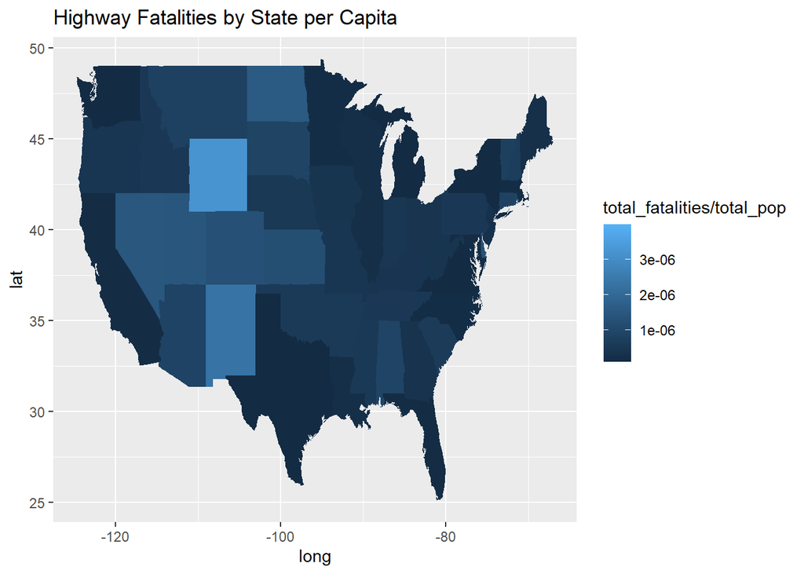

##### The above plot shows the rate of overall highway fatalities by state per capita, with Wyoming being notable for having the highest rate per capita, which makes sense due to the state having the smallest population against all the other states in the US.

##### Some reasons for this may be:

##### - Lowest state population, lots of mountains and dangerous road conditions

##### - Travelers who are unversed with these roads may lead to a disproportionate number of vehicular fatalities

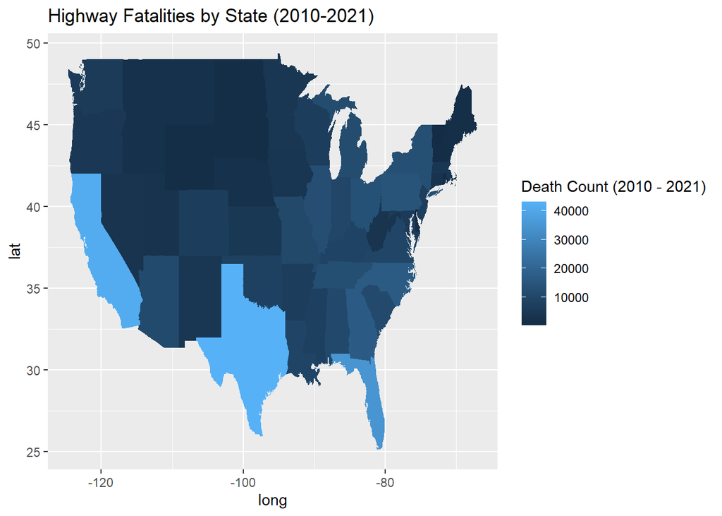

##### The above plot shows the total number of highway fatalities by state over the years that the data was collected (2010-2021). The three states with the highest highway fatalites are: Texas, California, and Flordia. With these states having some of the highest state populations compared to other states in the country, it would be common for these states to have the highest numbers. This also makes sense since during this time, more people were moving to Texas and Flordia during this time, increasing their populations. This could correspond to a rise in the total number of highway fatalites.

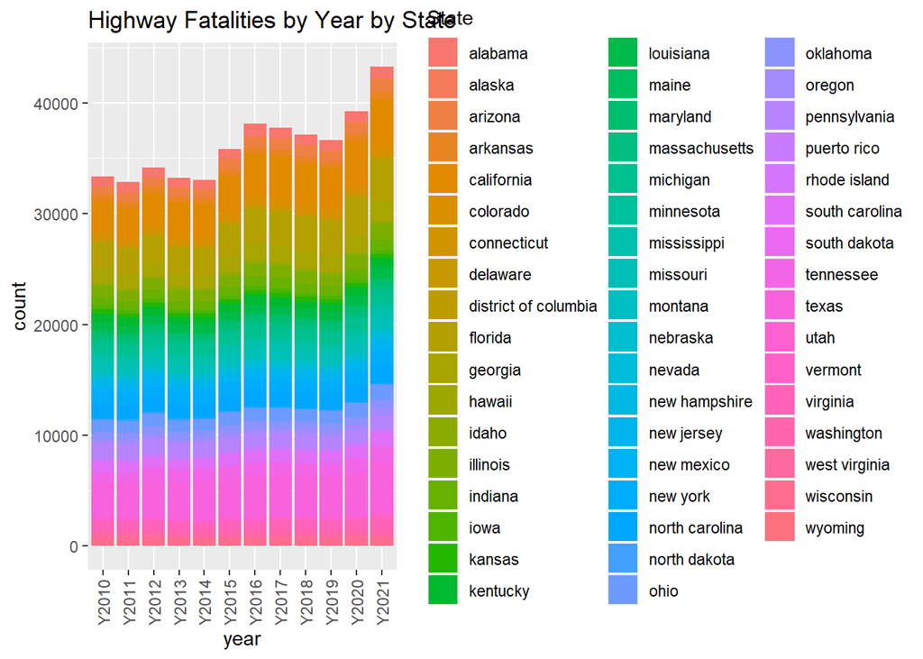

##### The above chart displays the total number of highway fatalites by year by each state. It’s interesting to see a spike in 2020-2021 during the Covid-19 lockdown years, since you would think less people would be out traveling, so you’d expect the totals to be lower, but they’re not.

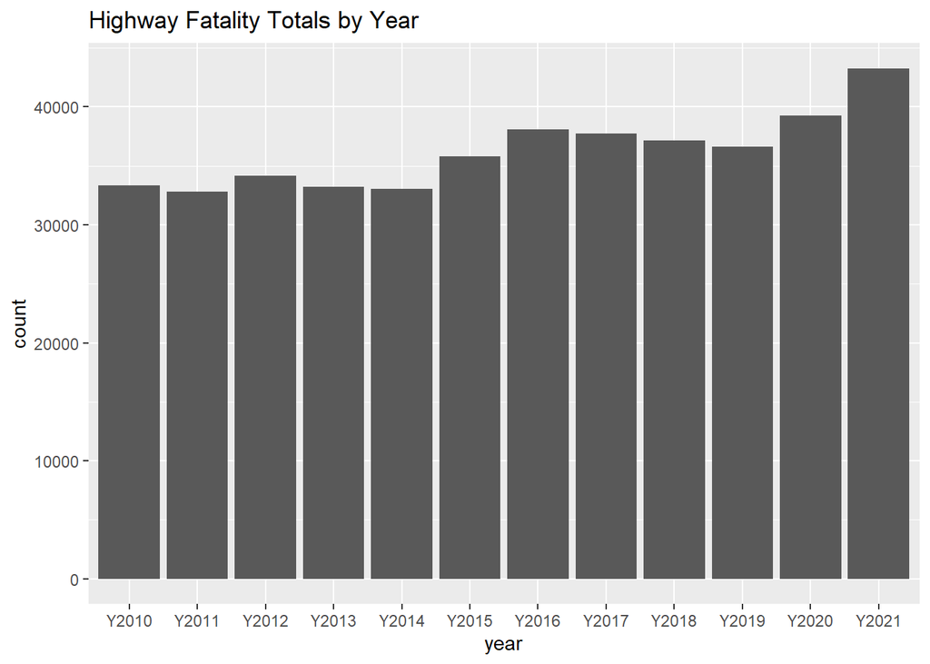

##### The chart above displays the Highway Fatality Totals by year from 2010-2021, where there is a noticable rise from the start, with a spike in the data in 2015-2016 and then again during 2020-2021.

#### Comparing highway fatalities to miles traveled in each state/overall from 2010-2021, sudden decrease in 2020 due to intial Covid-19 lockdown, with the total rising again in 2021 as more people started to travel again.

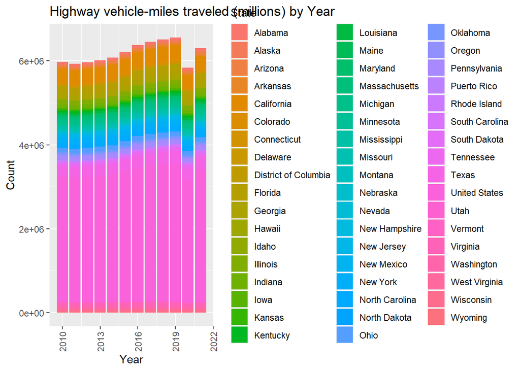

#### Comparing highway fatalities to licensed drivers in each state/overall from 2010-2021. Steady increase in new drivers as the population continues to grow over the years.

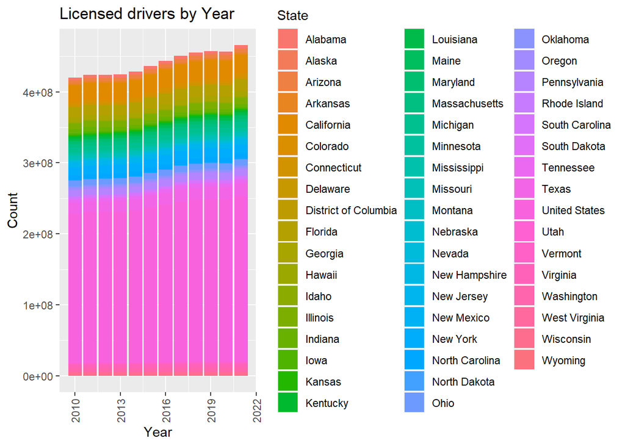

#### This bar graph shows the amount of pedestrian fatalities in each year, colored by state.

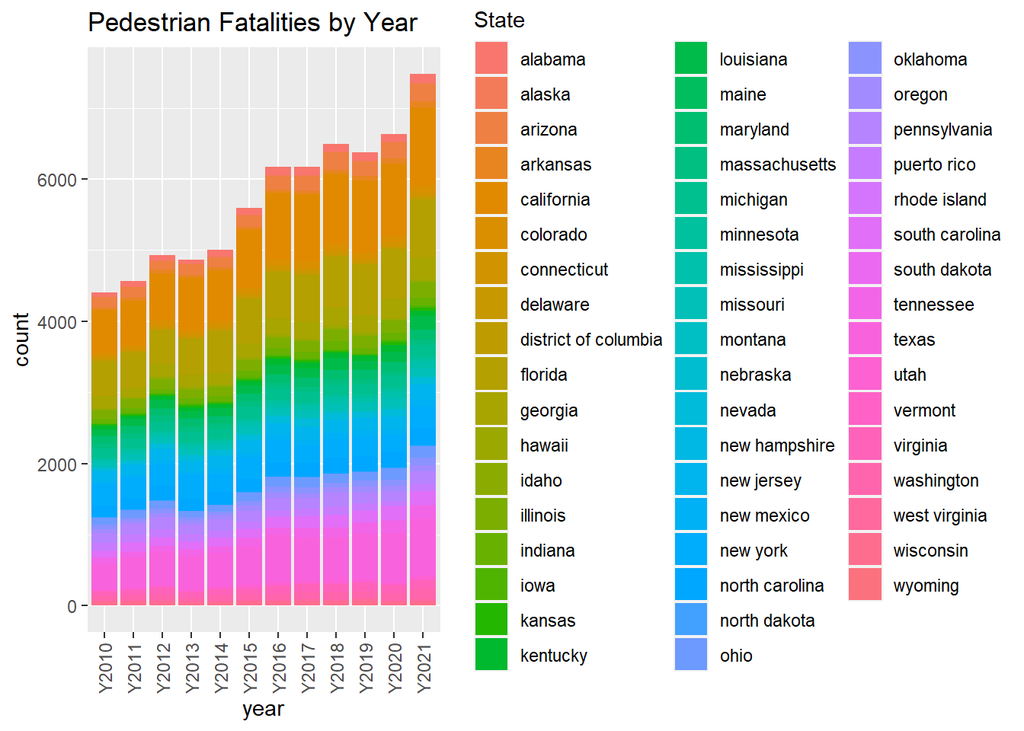

#### This graph shows the relative amount of pedestrian fatalities in each state over the entire 2010-2021 period, accounting for population density, with the map of the United States colored accordingly.

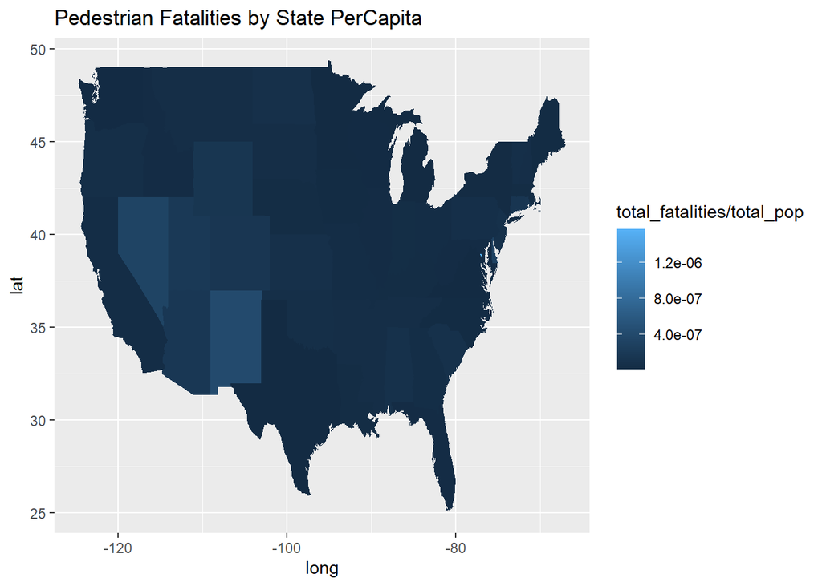

#### This graph shows the relative number of pedestrian fatalities in each state over the entire 2010-2021 period, with the map of the United States colored accordingly.

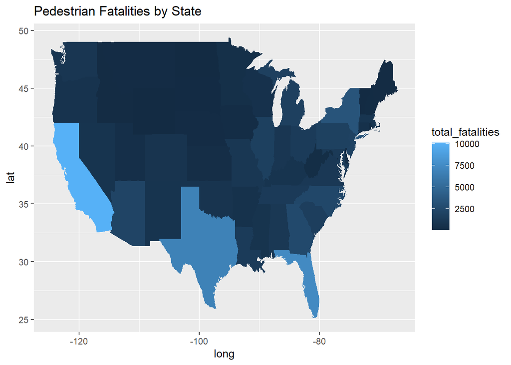

#### This bar graph shows the amount of other non-occupant fatalities in each year, colored by state.

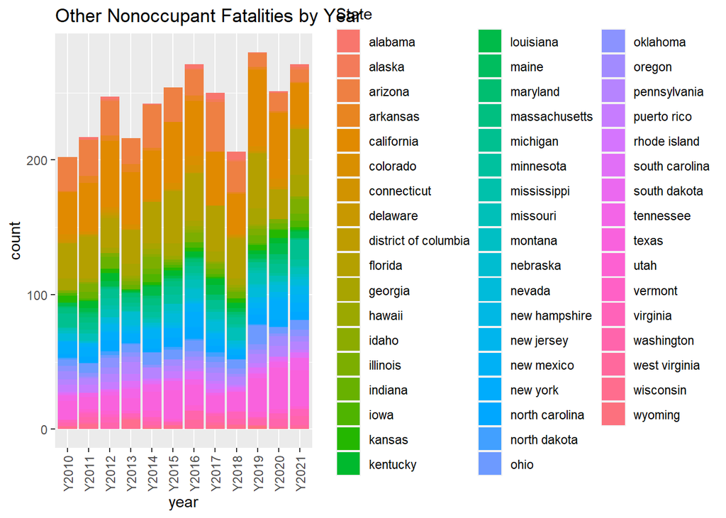

#### This graph shows the relative amount of other non-occupant fatalities in each state over the entire 2010-2021 period, accounting for population density, with the map of the United States colored accordingly.

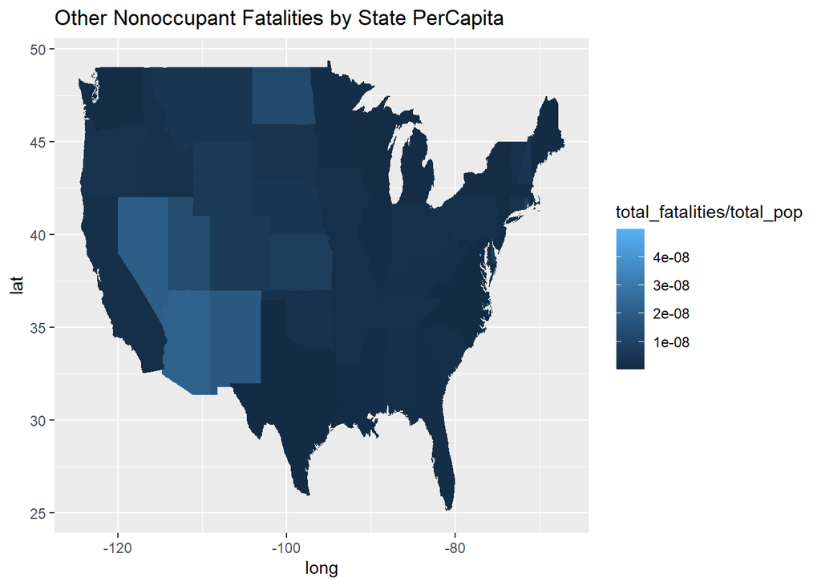

#### This graph shows the relative number of other non-occupant fatalities in each state over the entire 2010-2021 period, with the map of the United States colored accordingly.

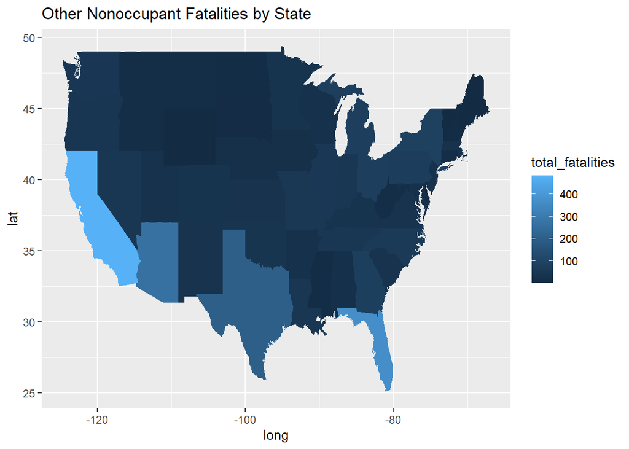

#### This bar graph shows the amount of other vehicle fatalities in each year, colored by state.

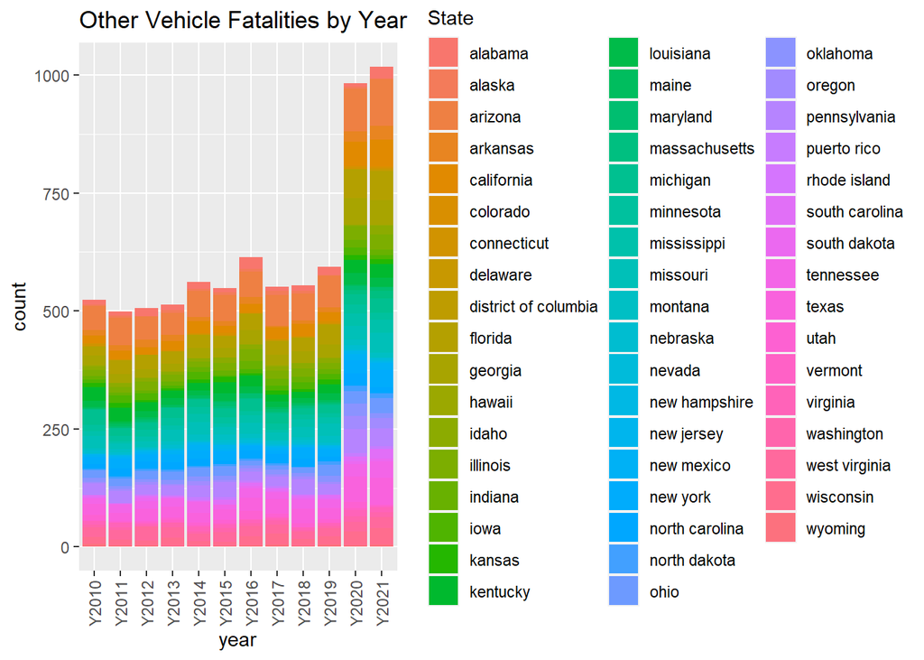

#### This graph shows the relative amount of other vehicle fatalities in each state over the entire 2010-2021 period, accounting for population density, with the map of the United States colored accordingly.

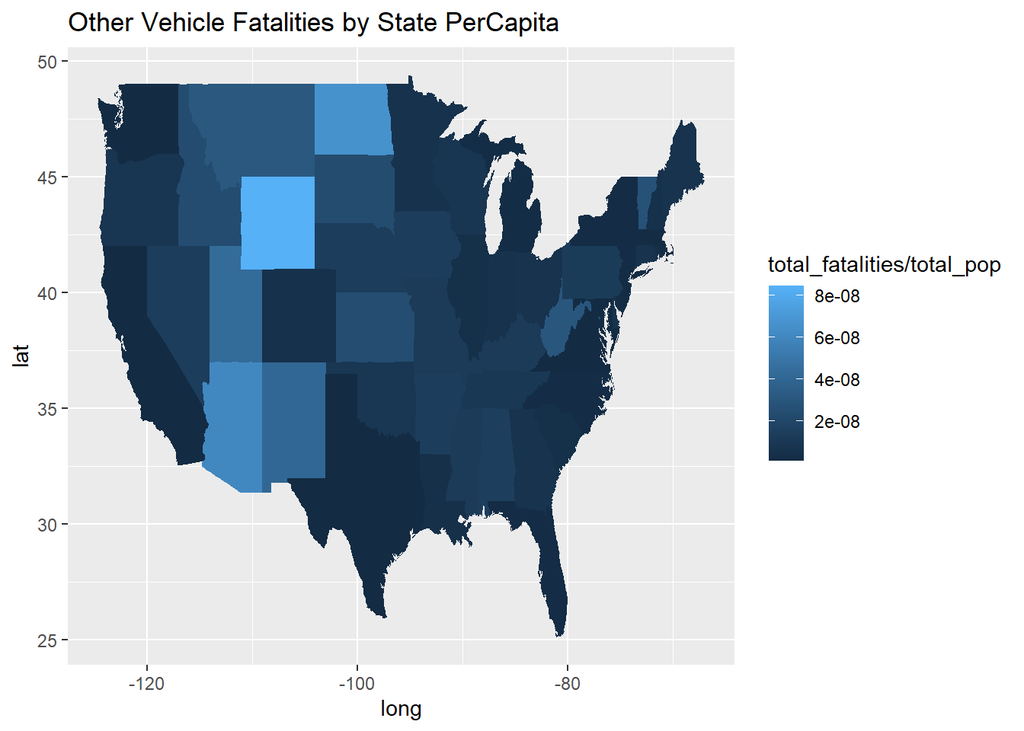

#### This graph shows the relative amount of other vehicle fatalities in each state over the entire 2010-2021 period, with the map of the United States colored accordingly.

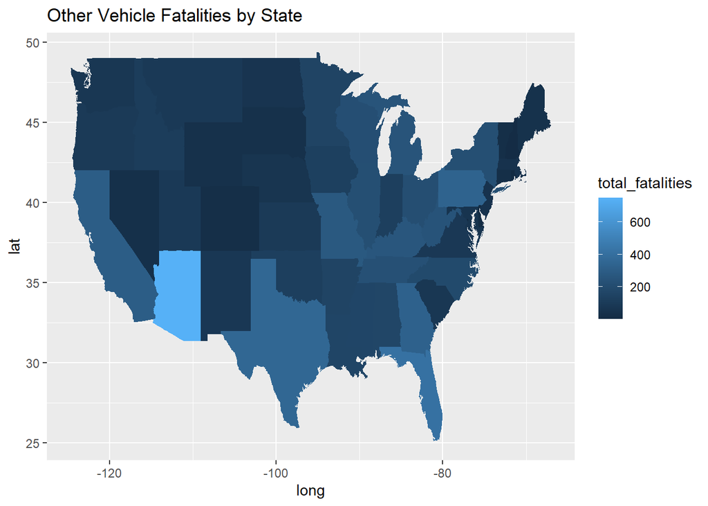

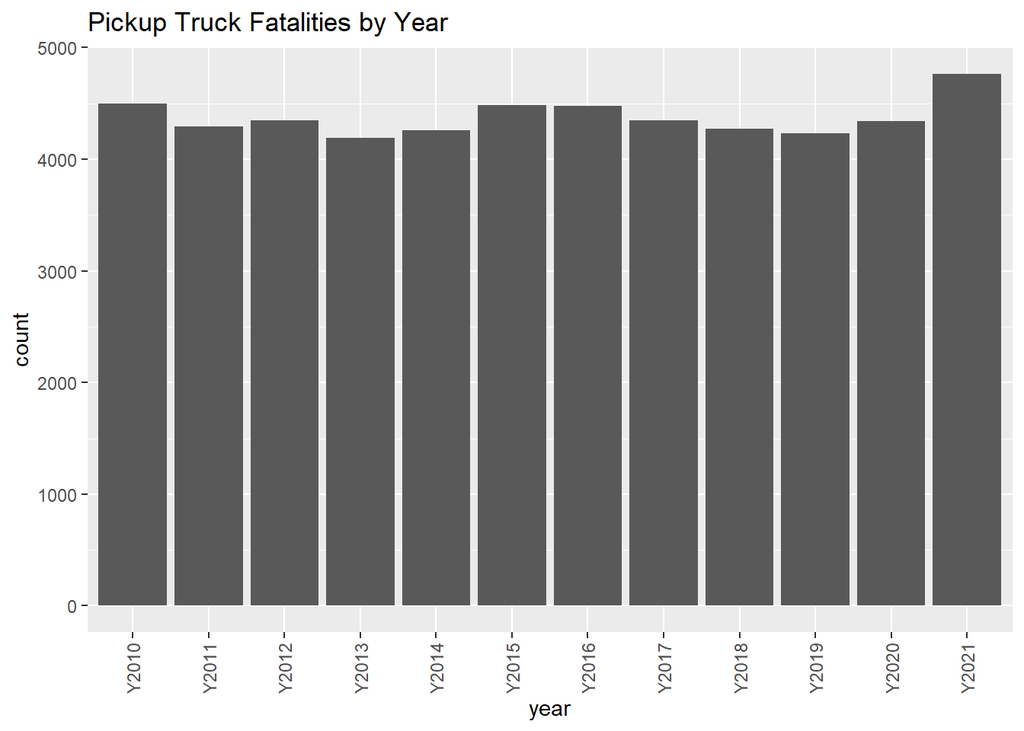

#### As is seen in this graph, there isn’t any distinct pattern, but there is a spike in 2021.

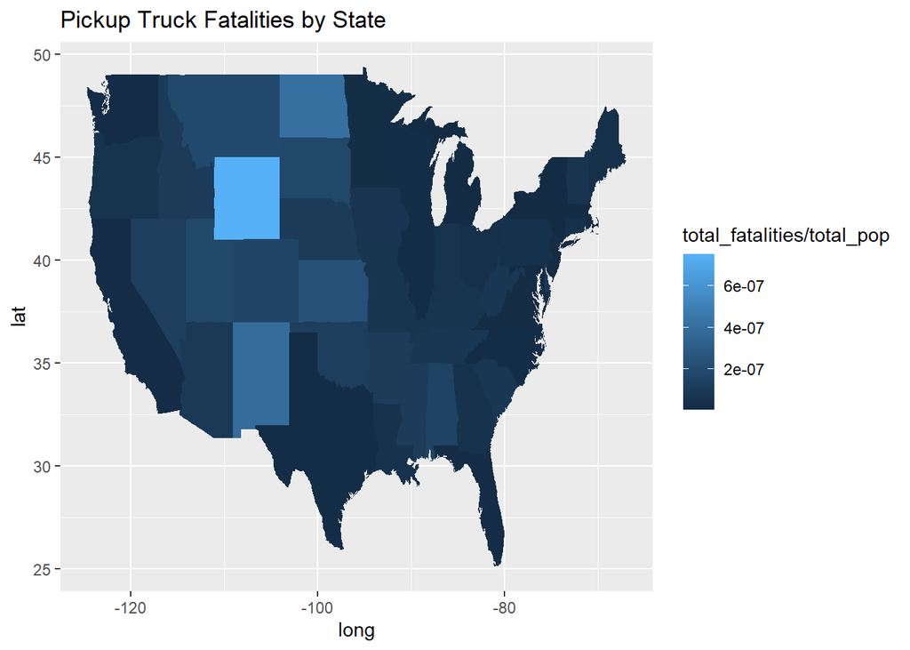

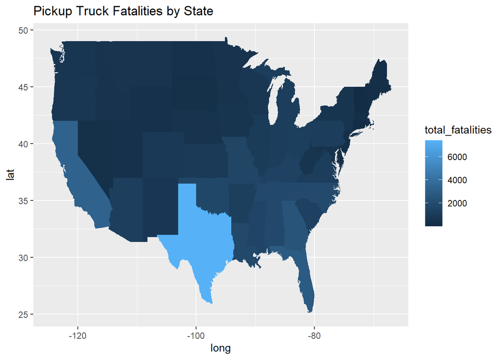

#### In these graphs, Wyoming clearly leads Pickup truck fatalities per capita, while Texas leads overall.

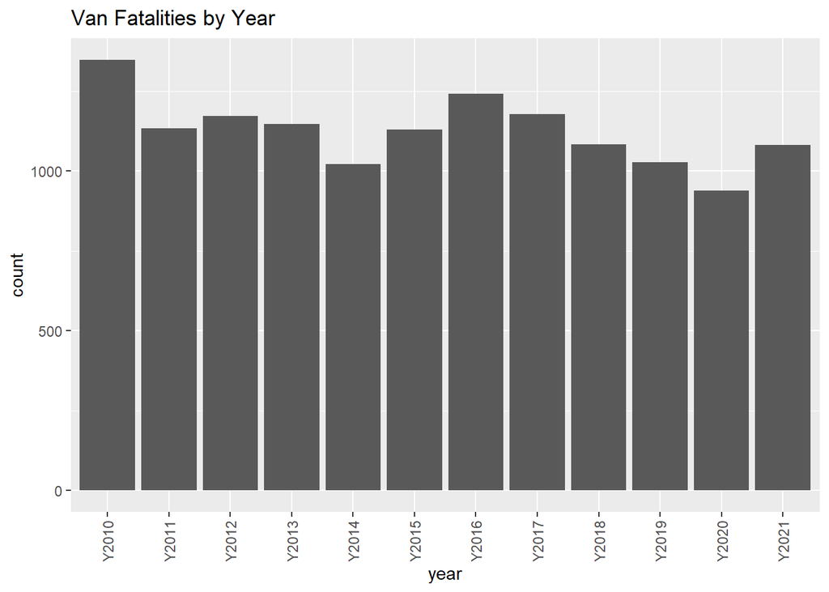

#### There was a pattern of decline in van fatalities until 2021 at the end.

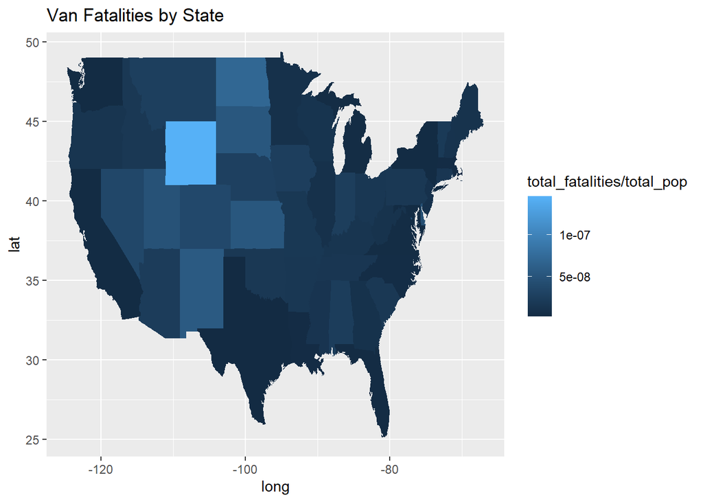

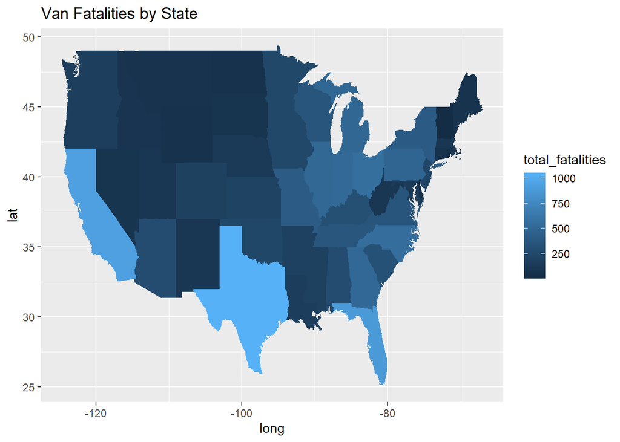

#### Once again, Wyoming leads in per capita fatalities, Texas, California, and Florida are all high totals. These states all make sense, given that Wyoming has the lowest population and the other 3 have the highest.

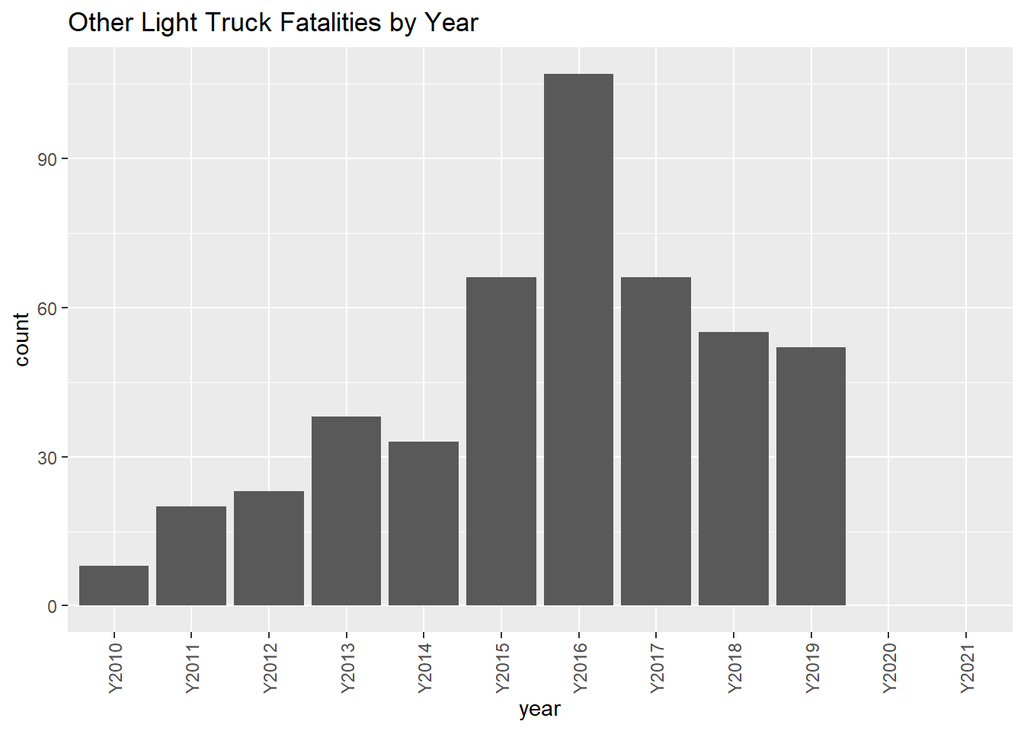

#### The data for 2020 and 2021 was not included in the dataset here, and there isn’t really a pattern, just a large spike in 2016.

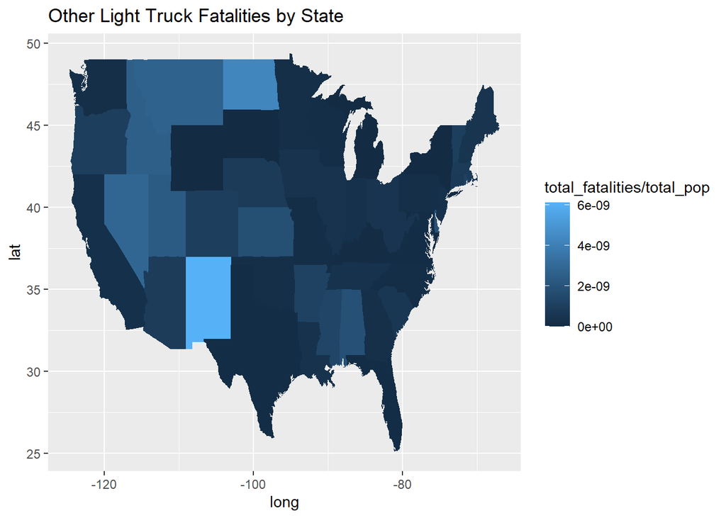

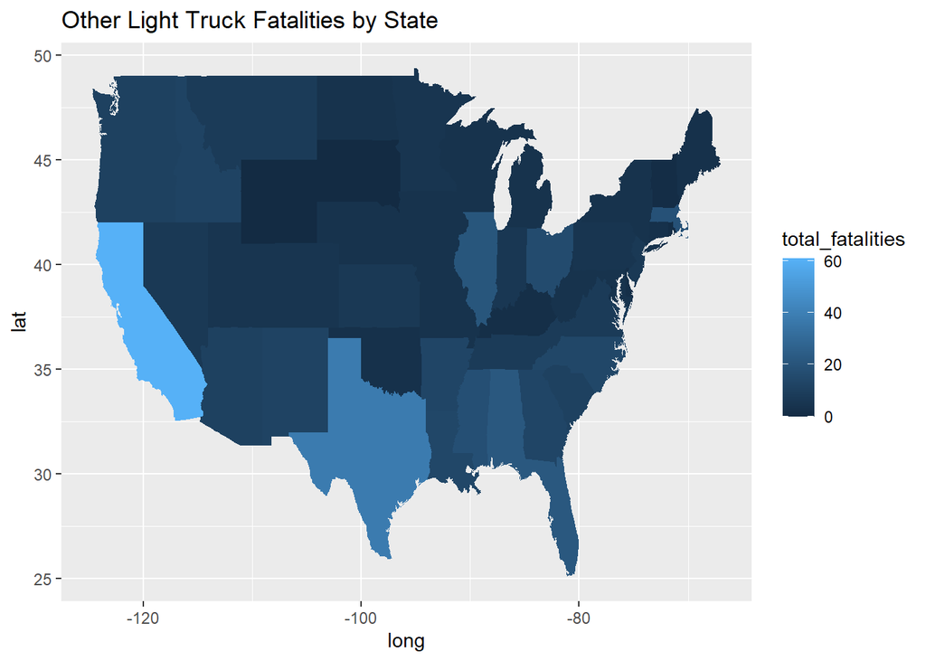

#### This time we can see New Mexico leads per capita fatalities, and California leads total.

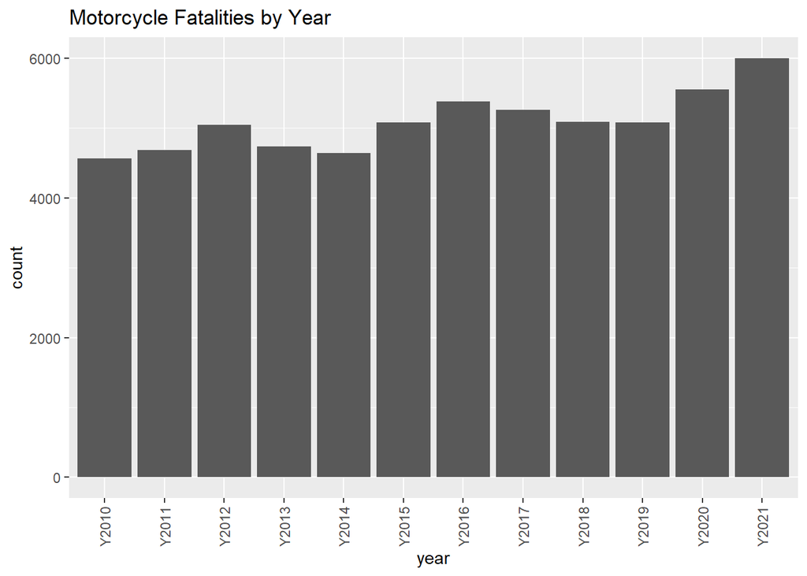

#### Motorcycle fatalities see a steady increase over time, with the highest being 2020 and 2021.

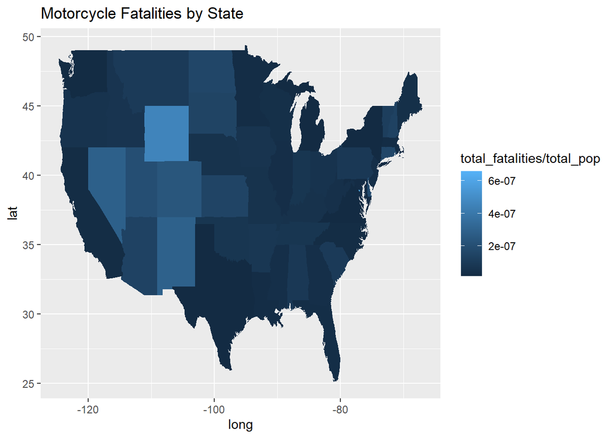

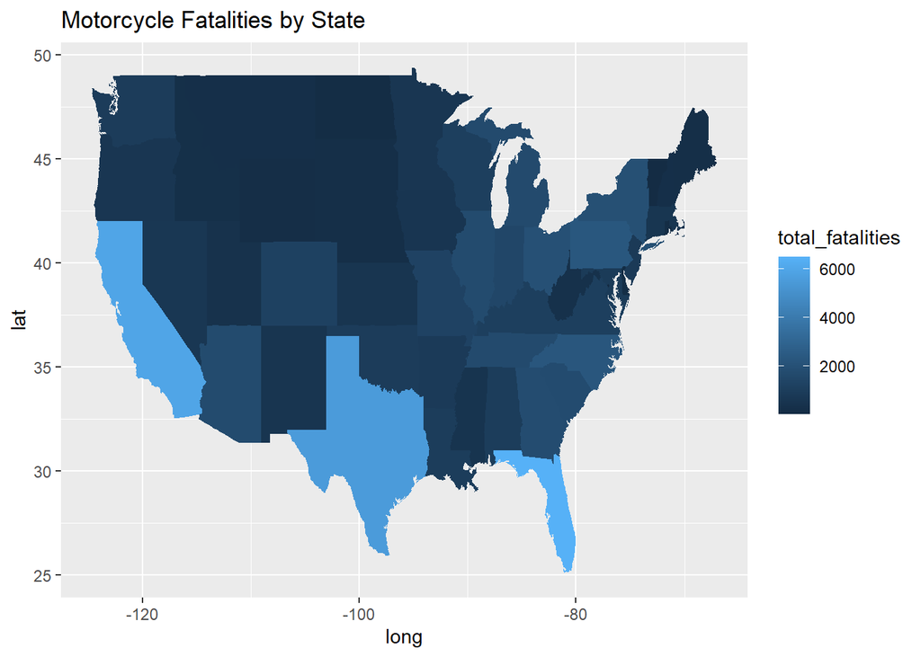

#### Then again we see Wyoming lead per capita fatalities, with Texas, California, and Florida leading the totals.

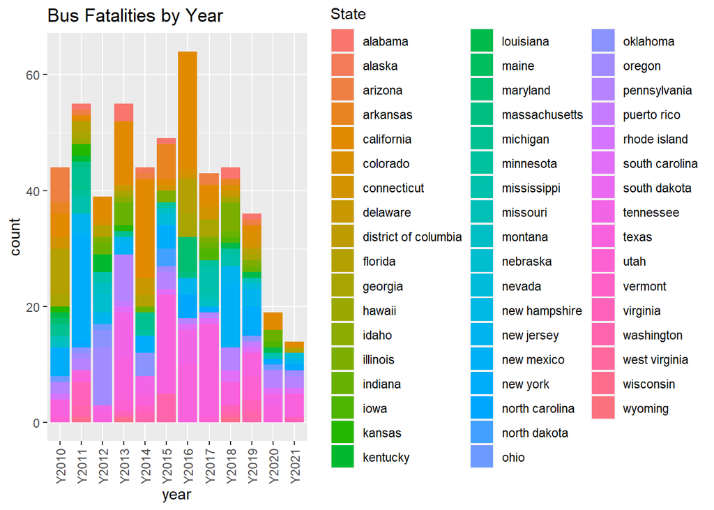

#### Here, the bus fatality totals per capita are labeled by state, with New Mexico interestingly having the highest rate per capita out of any state.

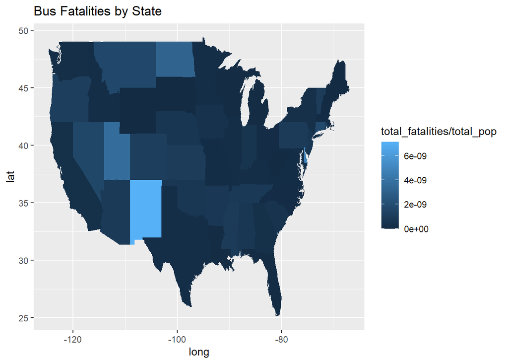

#### Looking into this, we observed the total number of bus fatalites overall by state, with Texas, California, and New York having the highest values. This makes sense due to their large populations, large urban populations, and extensive use of bus systems in their urban areas.

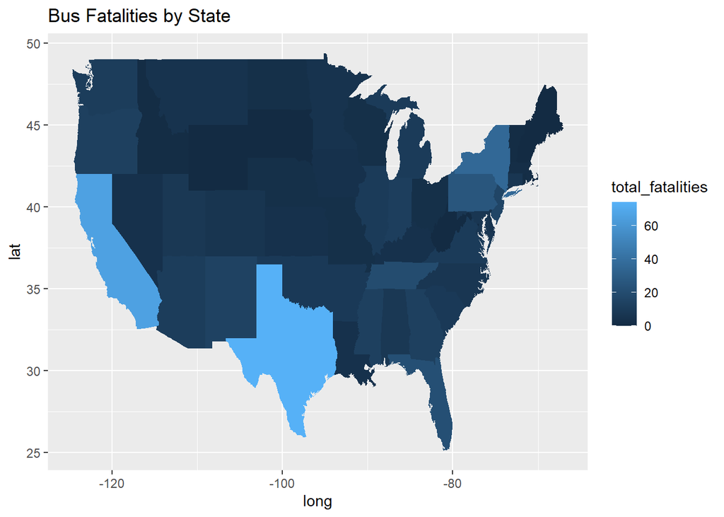

#### Observing large truck fatalities across the country, which mainly involves semi-trucks and the movement of goods, there is an increase of fatalites occuring as the years go on. This could be due to a rise in consumer product shipping, the internet and online shopping becoming a bigger part in American commerce, leading to more large trucks on the road, causing more accidents. This could also be due to a rush for a need for more truckers, causing there to be more inexperienced truckers on the road.

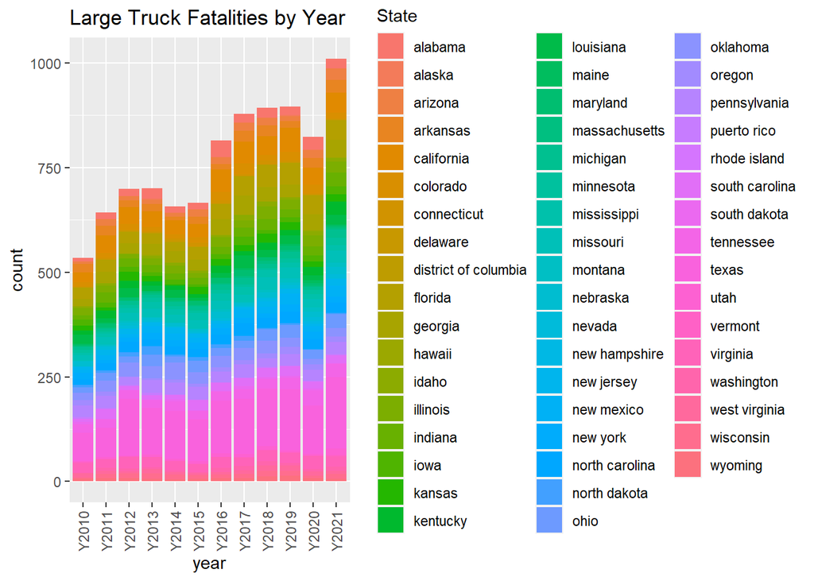